# STA 141A: Predicting Wildfire Incidence in the United States

## Overview

The goal of this final project is to develop a prediction model for the incidence and location of notable wildfires in the United States ([link](https://www.kaggle.com/datasets/rtatman/188-million-us-wildfires/data)). You will use historical wildfire records to estimate the probability that a wildfire will occur in a given geographic area during a future month.

A full modeling pipeline is expected, including:

- Careful problem formulation and data preprocessing
- Exploratory analysis to motivate modeling choices
- Predictive modeling with appropriate validation
- Clear interpretation and communication of results

Students are expected to submit a final written report, organized according to the sections described below. Each student is expected to write their own reproducible report, but discussion is encouraged.

## Data and background

You can find and download a subset of historical wildfire records derived from the Kaggle dataset *“188 Million US Wildfires”*. The dataset includes wildfire ignition locations, discovery dates, containment dates, and final burned area across the contiguous United States. You are encouraged, but not required, to use the full dataset from the original source.

Wildfires vary widely in size, and the vast majority of recorded fires are very small and quickly contained. Modeling all recorded fires would lead to extreme class imbalance and would obscure the dynamics of fires that are operationally and scientifically meaningful.

To address this, you may filter the raw wildfire records to retain only “notable” fires. A recommended cutoff is to retain only the wildfires with final burned area $\geq$ 300 acres. This threshold is consistent with operational wildfire reporting standards used by U.S. fire management agencies, where *large wildland fires* are commonly defined as: $\geq$ 100 acres in timber fuel models, or $\geq$ 300 acres in grass or brush fuel models

**Alternative Cutoffs.** You may choose an alternative cutoff if you clearly justify your choice. Any alternative cutoff must be clearly justified in writing and applied consistently throughout the project.

I used 1000 acres instead of 300 acres to create a stricter definition of notable wildfire. This choice reduces the number of moderately sized fires included in the positive class and focuses the modeling task on larger wildfire events. Although 300 acres was the recommended cutoff, the alternative cutoff was applied consistently throughout the project.

## Prediction Task

The prediction task is formulated as a binary classification problem with spatial and temporal structure.

- **Outcome**  
  For each spatial unit and month, define a binary variable indicating whether at least one notable wildfire occurs during that month.
- **Spatial unit**  
  You may choose an appropriate spatial unit (e.g., grid cells, counties, or other geographic partitions). The choice should balance spatial resolution, interpretability, and data sparsity.
- **Temporal unit**  
  Month. You may refine your resolution to week or day with clear justification.
- **Predictors**  
  You may select any variables in the dataset as your predictors. External data sources (e.g., weather or land cover) are allowed but not required.

spatial unit = STATE temporal unit = month outcome = whether at least one notable fire occurs predictors = total_fires, notable_fires, avg_fire_size, max_fire_size, month

I used state as the spatial unit because it provides a simple and interpretable geographic partition while avoiding excessive sparsity that could arise from using much finer spatial units.

## Report Structure and Required Sections

Your final report must contain an **abstract** and the following **five** sections. Each section should combine clear explanation, appropriate visual or tabular outputs, and interpretation.

You may add an optional Introduction or Background section to improve the exposition of the report.

### 1. Data Preprocessing

This section should clearly explain how the raw wildfire data are transformed into the final dataset used for modeling.

The report should explain

- How notable fires are identified and filtered
- How space–time units are constructed (e.g., grid-by-month)
- How the binary outcome variable is defined
- How predictors are constructed or aggregated
- How missing data or edge cases are handled

**Minimum required output:** A summary table describing the final dataset used for predictive modeling.

```r
library(tidyverse)
library(lubridate)
fires = read_csv("wildfires_sample_100k.csv")
head(fires)
glimpse(fires)
dat = fires
dat$DISCOVERY_DATE = as.Date(dat$DISCOVERY_DATE, origin = "1970-01-01")
dat$year = year(dat$DISCOVERY_DATE)
dat$month = month(dat$DISCOVERY_DATE)
dat$notable_fire = ifelse(dat$FIRE_SIZE >= 1000, 1, 0)
dat2 = dat[, c("STATE", "year", "month", "FIRE_SIZE", "notable_fire")]
dat2 = dat2[!is.na(dat2$STATE), ]
dat2 = dat2[!is.na(dat2$year), ]
dat2 = dat2[!is.na(dat2$month), ]
dat2 = dat2[!is.na(dat2$FIRE_SIZE), ]
model_dat = dat2 %>%
  group_by(STATE, year, month) %>%
  summarize(total_fires = n(),
            notable_fires = sum(notable_fire),
            avg_fire_size = mean(FIRE_SIZE),
            max_fire_size = max(FIRE_SIZE),
            outcome = ifelse(notable_fires > 0, 1, 0),
            .groups = "drop")
head(model_dat)
summary(model_dat)
```

A tibble: 6 x 39

| OBJECTID <dbl> | FOD_ID <dbl> | FPA_ID <chr> | SOURCE_SYSTEM_TYPE <chr> | SOURCE_SYSTEM <chr> | NWCG_REPORTING_AGENCY <chr> | NWCG_REPORTING_UNIT_ID <chr> | NWCG_REPORTING_UNIT_NAME <chr> | SOURCE_REPORTING_UNIT <chr> | SOURCE_REPORTING_UNIT_NAME <chr> | ... | FIRE_SIZE_CLASS <chr> | LATITUDE <dbl> | LONGITUDE <dbl> | OWNER_CODE <dbl> | OWNER_DESCR <chr> | STATE <chr> | COUNTY <chr> | FIPS_CODE <chr> | FIPS_NAME <chr> | Shape <chr> |
| --- | --- | --- | --- | --- | --- | --- | --- | --- | --- | --- | --- | --- | --- | --- | --- | --- | --- | --- | --- | --- |
| 16 | 16 | FS-1418876 | FED | FS-FIRESTAT | FS | USCAENF | Eldorado National Forest | 0503 | Eldorado National Forest | ... | A | 38.56417 | -120.5422 | 5 | USFS | CA | 17 | 017 | El Dorado | <raw> |
| 68 | 68 | FS-1419017 | FED | FS-FIRESTAT | FS | USMTKNF | Kootenai National Forest | 0114 | Kootenai National Forest | ... | A | 48.40778 | -115.5578 | 13 | STATE OR PRIVATE | MT | 53 | 053 | Lincoln | <raw> |
| 73 | 74 | FS-1419045 | FED | FS-FIRESTAT | FS | USMTKNF | Kootenai National Forest | 0114 | Kootenai National Forest | ... | B | 48.89444 | -115.1653 | 13 | STATE OR PRIVATE | MT | 53 | 053 | Lincoln | <raw> |
| 111 | 112 | FS-1419134 | FED | FS-FIRESTAT | FS | USCASNF | Sierra National Forest | 0515 | Sierra National Forest | ... | A | 37.04417 | -119.3439 | 13 | STATE OR PRIVATE | CA | NA | NA | NA | <raw> |
| 191 | 194 | FS-1419315 | FED | FS-FIRESTAT | FS | USNMCAF | Carson National Forest | 0302 | Carson National Forest | ... | A | 36.90000 | -107.3281 | 5 | USFS | NM | 39 | 039 | Rio Arriba | <raw> |
| 228 | 231 | FS-1419384 | FED | FS-FIRESTAT | FS | USAZASF | Apache-Sitgreaves National Forest | 0301 | Apache-Sitgreaves National Forest | ... | A | 33.66000 | -109.3550 | 5 | USFS | AZ | 11 | 011 | Greenlee | <raw> |

```
Rows: 100,000
Columns: 39
$ OBJECTID                   <dbl> 16, 68, 73, 111, 191, 228, 264, 269, 294, 3~
$ FOD_ID                     <dbl> 16, 68, 74, 112, 194, 231, 268, 274, 299, 3~
$ FPA_ID                     <chr> "FS-1418876", "FS-1419017", "FS-1419045", "~
$ SOURCE_SYSTEM_TYPE         <chr> "FED", "FED", "FED", "FED", "FED", "FED", "~
$ SOURCE_SYSTEM              <chr> "FS-FIRESTAT", "FS-FIRESTAT", "FS-FIRESTAT"~
$ NWCG_REPORTING_AGENCY      <chr> "FS", "FS", "FS", "FS", "FS", "FS", "FS", "~
$ NWCG_REPORTING_UNIT_ID     <chr> "USCAENF", "USMTKNF", "USMTKNF", "USCASNF",~
$ NWCG_REPORTING_UNIT_NAME   <chr> "Eldorado National Forest", "Kootenai Natio~
$ SOURCE_REPORTING_UNIT      <chr> "0503", "0114", "0114", "0515", "0302", "03~
$ SOURCE_REPORTING_UNIT_NAME <chr> "Eldorado National Forest", "Kootenai Natio~
$ LOCAL_FIRE_REPORT_ID       <chr> "103", "43", "33", "2", "279", "16", "37", ~
$ LOCAL_INCIDENT_ID          <chr> "22", "015", "008", "01", "279", "06", "014~
$ FIRE_CODE                  <chr> NA, "BYE5", "BXR5", "BGJ2", "F279", "BEX6",~
```

[output cut: 26 more lines]

A tibble: 6 x 8

| STATE <chr> | year <dbl> | month <dbl> | total_fires <int> | notable_fires <dbl> | avg_fire_size <dbl> | max_fire_size <dbl> | outcome <dbl> |
| --- | --- | --- | --- | --- | --- | --- | --- |
| AK | 8674 | 6 | 11 | 0 | 1.481818 | 12 | 0 |
| AK | 8674 | 7 | 11 | 1 | 2330.027273 | 25600 | 1 |
| AK | 8674 | 8 | 10 | 0 | 13.190000 | 80 | 0 |
| AK | 8674 | 9 | 4 | 0 | 0.375000 | 1 | 0 |
| AK | 8675 | 5 | 1 | 0 | 21.000000 | 21 | 0 |
| AK | 8675 | 6 | 11 | 0 | 11.345455 | 60 | 0 |

```
    STATE                year          month         total_fires
 Length:8759        Min.   :8674   Min.   : 1.000   Min.   :  1.00
 Class :character   1st Qu.:8681   1st Qu.: 4.000   1st Qu.:  2.00
 Mode  :character   Median :8687   Median : 7.000   Median :  5.00
                    Mean   :8686   Mean   : 6.827   Mean   : 11.42
                    3rd Qu.:8692   3rd Qu.:10.000   3rd Qu.: 14.00
                    Max.   :8698   Max.   :12.000   Max.   :213.00
 notable_fires     avg_fire_size       max_fire_size         outcome
 Min.   :0.00000   Min.   :    0.001   Min.   :     0.0   Min.   :0.00000
 1st Qu.:0.00000   1st Qu.:    0.540   1st Qu.:     1.0   1st Qu.:0.00000
 Median :0.00000   Median :    2.550   Median :     8.0   Median :0.00000
 Mean   :0.06759   Mean   :   67.336   Mean   :   637.7   Mean   :0.05058
 3rd Qu.:0.00000   3rd Qu.:   10.660   3rd Qu.:    58.0   3rd Qu.:0.00000
 Max.   :8.00000   Max.   :68910.628   Max.   :344833.0   Max.   :1.00000
```

The original wildfire dataset is recorded at the individual fire level, where each row corresponds to one wildfire event. However, the goal of this project is to predict whether a notable wildfire occurs in a given place and time period, so the raw data must be transformed into a modeling dataset that matches this prediction task. To do this, I converted the fire-level data into a state-by-month dataset, where each row represents one state in one month. This makes the final dataset consistent with the prediction problem and also makes the data preparation process reproducible.

Predictors and aggregation: To build the final dataset, I grouped the fire-level data by STATE, year, and month, and then aggregated the observations within each state-month. I created summary variables including the total number of fires, number of notable fires, average fire size, and maximum fire size. These variables summarize wildfire activity in each unit and can be used as predictors or descriptive variables in later modeling. This aggregation step is important because it transforms the raw event-level dataset into a structured dataset suitable for prediction at the state-month level.

Final modeling dataset: The final modeling dataset contains one row per state-month. Its main variables are STATE, year, month, total_fires, notable_fires, avg_fire_size, max_fire_size, and outcome. This final dataset is the one used for predictive modeling. It is clearly tied to the prediction task because the predictors and outcome are all defined at the same state-month level.

### 2. Exploratory Data Analysis

The purpose of this section is to build intuition about the data and to justify modeling decisions.

You may explore questions such as

- How does wildfire incidence vary across space?
- How strong is seasonality?
- How do predictors differ between fire and non-fire observations?
- Are there trends over time?

**Minimum required output:** The report should include at least **two** exploratory plots that demonstrate the spatial and temporal patterns of wildfires. Each plot should be accompanied by a brief interpretation.

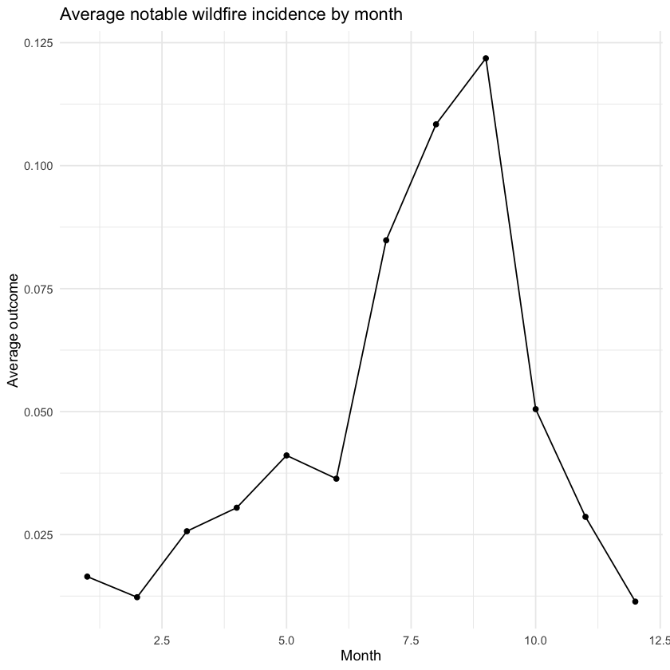

```r
library(tidyverse)
month_dat = model_dat %>%
  group_by(month) %>%
  summarize(mean_outcome = mean(outcome),
            .groups = "drop")

ggplot(month_dat, aes(x = month, y = mean_outcome)) +
  geom_line() +
  geom_point() +
  labs(title = "Average notable wildfire incidence by month",
       x = "Month",
       y = "Average outcome") +
  theme_minimal()
```

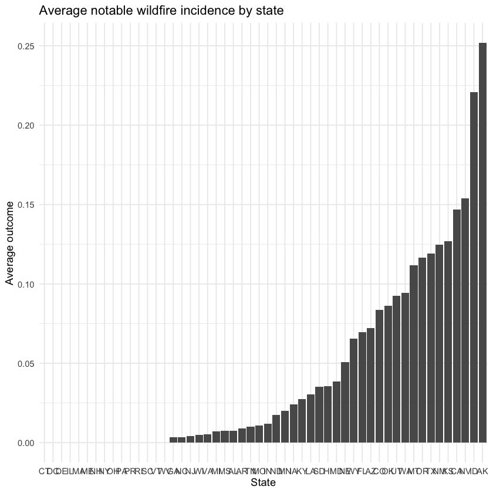

```r
library(tidyverse)
state_dat = model_dat %>%
  group_by(STATE) %>%
  summarize(mean_outcome = mean(outcome),
            .groups = "drop") %>%
  arrange(mean_outcome)
ggplot(state_dat, aes(x = reorder(STATE, mean_outcome), y = mean_outcome)) +
  geom_col() +
  labs(title = "Average notable wildfire incidence by state",
       x = "State",
       y = "Average outcome") +
  theme_minimal()
```

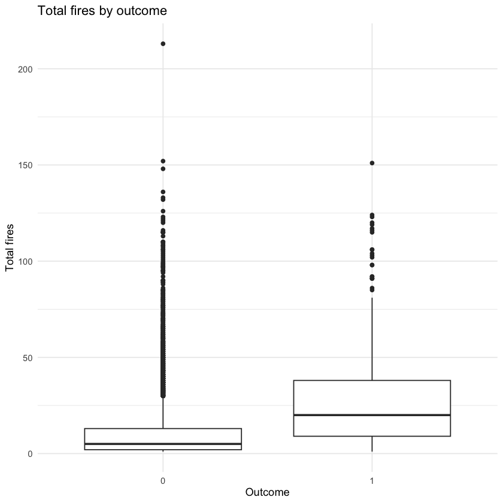

```r
library(tidyverse)
ggplot(model_dat, aes(x = factor(outcome), y = total_fires)) +
  geom_boxplot() +
  labs(title = "Total fires by outcome",
       x = "Outcome",
       y = "Total fires") +
  theme_minimal()
```

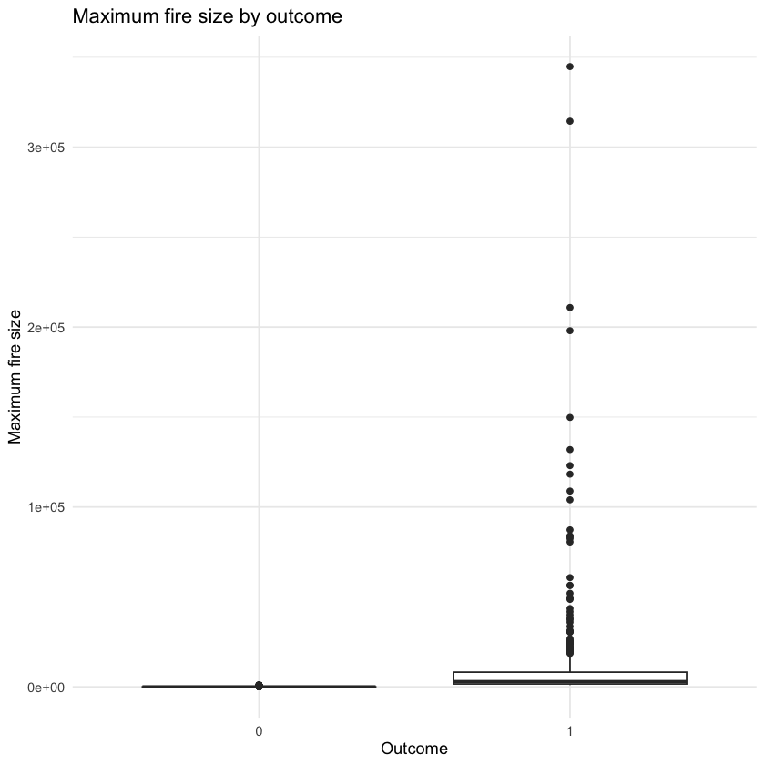

```r
library(tidyverse)
ggplot(model_dat, aes(x = factor(outcome), y = max_fire_size)) +
  geom_boxplot() +
  labs(title = "Maximum fire size by outcome",
       x = "Outcome",
       y = "Maximum fire size") +
  theme_minimal()
```

Afrer analysis the result of the graph, the graph 1 shows that the average probability of a notabe wild fire is not constant across the year, soem months have a cleary hgiher average outcome values than other, like in the summer months,(5.5-10) it's the summit through whole graph, which suggest that wild fire incidence has a strong seasonal pattern, in other words, notable wildfire are more likely or high frequency during certain time, This pattern suggests that month is an important predictor and should be consider in the modleing stage.

Together, Graphs 3 and 4 show that wildfire activity variables differ between the two outcome groups. In particular, state-months with a notable wildfire tend to have both more fires overall and larger maximum fire sizes. These patterns support using wildfire summary variables as predictors in the classification models.

The analysis suggests that wildfire incidence varies across both space and time. Spatially, some states have much higher average notable wildfire incidence than others, indicating clear geographic heterogeneity. Temporally, the monthly pattern shows strong seasonality, with certain months having much higher wildfire incidence than others. In addition, the predictor distributions differ between positive and negative outcome groups, since state-months with notable wildfires tend to have more fires overall and larger maximum fire sizes. Finally, yearly summaries can be used to assess whether there are broader long-term trends over time in addition to seasonal effects.

### 3. Modeling

In this section, you will specify and justify the predictive models. You must fit at least **two** models.

1. **Baseline model.** A simple and interpretable model (e.g., logistic regression) that establishes a performance benchmark. Attend discussion session to get code for this baseline model!
2. **Model of your choice.** This is the model that you choose, after careful examination of the dataset. Ideally, your model should outperform the baseline model.

**Minimum required output:** Description of both the baseline model and the model of your choice.

A tibble: 6 x 8

| STATE <chr> | year <dbl> | month <fct> | total_fires <int> | notable_fires <dbl> | avg_fire_size <dbl> | max_fire_size <dbl> | outcome <dbl> |
| --- | --- | --- | --- | --- | --- | --- | --- |
| AK | 8674 | 6 | 11 | 0 | 1.481818 | 12 | 0 |
| AK | 8674 | 7 | 11 | 1 | 2330.027273 | 25600 | 1 |
| AK | 8674 | 8 | 10 | 0 | 13.190000 | 80 | 0 |
| AK | 8674 | 9 | 4 | 0 | 0.375000 | 1 | 0 |
| AK | 8675 | 5 | 1 | 0 | 21.000000 | 21 | 0 |
| AK | 8675 | 6 | 11 | 0 | 11.345455 | 60 | 0 |

```
Rows: 8,759
Columns: 8
$ STATE         <chr> "AK", "AK", "AK", "AK", "AK", "AK", "AK", "AK", "AK", "A~
$ year          <dbl> 8674, 8674, 8674, 8674, 8675, 8675, 8675, 8675, 8675, 86~
$ month         <fct> 6, 7, 8, 9, 5, 6, 7, 8, 9, 10, 4, 5, 6, 7, 8, 9, 10, 11,~
$ total_fires   <int> 11, 11, 10, 4, 1, 11, 14, 21, 9, 3, 1, 2, 5, 11, 6, 6, 1~
$ notable_fires <dbl> 0, 1, 0, 0, 0, 0, 0, 1, 0, 0, 0, 0, 0, 2, 0, 0, 0, 0, 0,~
$ avg_fire_size <dbl> 1.4818182, 2330.0272727, 13.1900000, 0.3750000, 21.00000~
$ max_fire_size <dbl> 12.0, 25600.0, 80.0, 1.0, 21.0, 60.0, 130.0, 2037.0, 3.5~
$ outcome       <dbl> 0, 1, 0, 0, 0, 0, 0, 1, 0, 0, 0, 0, 0, 1, 0, 0, 0, 0, 0,~
```

```
Call:
glm(formula = outcome ~ total_fires + notable_fires + avg_fire_size +
    max_fire_size + month, family = "binomial", data = train_dat)

Coefficients:
                Estimate Std. Error z value Pr(>|z|)
(Intercept)   -2.655e+01  1.885e+04  -0.001    0.999
total_fires    2.062e-03  2.544e+02   0.000    1.000
notable_fires  5.138e+01  1.335e+04   0.004    0.997
avg_fire_size  4.562e-05  7.644e+00   0.000    1.000
max_fire_size  1.825e-06  7.337e-01   0.000    1.000
month2         1.355e-04  2.612e+04   0.000    1.000
month3        -1.004e-02  2.531e+04   0.000    1.000
month4         1.581e-02  2.380e+04   0.000    1.000
month5         3.242e-02  2.265e+04   0.000    1.000
month6         5.621e-02  2.295e+04   0.000    1.000
month7         2.594e-02  2.321e+04   0.000    1.000
month8         1.045e-01  2.275e+04   0.000    1.000
month9         8.724e-02  2.303e+04   0.000    1.000
month10        5.541e-02  2.323e+04   0.000    1.000
month11        5.319e-02  2.359e+04   0.000    1.000
month12       -5.100e-03  2.434e+04   0.000    1.000

(Dispersion parameter for binomial family taken to be 1)

    Null deviance: 2.4427e+03  on 6130  degrees of freedom
Residual deviance: 4.3181e-08  on 6115  degrees of freedom
AIC: 32

Number of Fisher Scoring iterations: 25
```

```
         Actual
Predicted    0    1
        0 2493    0
        1    0  135
```

1

```
n= 6131

node), split, n, loss, yval, (yprob)
      * denotes terminal node

1) root 6131 308 0 (0.9497635 0.0502365)
  2) notable_fires< 0.5 5823   0 0 (1.0000000 0.0000000) *
  3) notable_fires>=0.5 308   0 1 (0.0000000 1.0000000) *
```

```
         Actual
Predicted    0    1
        0 2493    0
        1    0  135
```

1

A data.frame: 2 x 2

| Model <chr> | Accuracy <dbl> |
| --- | --- |
| Logistic Regression | 1 |
| Decision Tree | 1 |

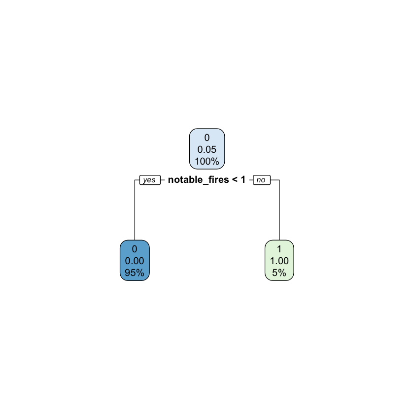

```r
library(tidyverse)
library(rpart)
library(rpart.plot)
head(model_dat)
glimpse(model_dat)
model_dat$month = as.factor(model_dat$month)
set.seed(141)
n = nrow(model_dat)
train_id = sample(1:n, size = 0.7 * n)
train_dat = model_dat[train_id, ]
test_dat = model_dat[-train_id, ]

#  model1 : logistic regression
log_mod = glm(outcome ~ total_fires + notable_fires + avg_fire_size +
                max_fire_size + month,
              data = train_dat,
              family = "binomial")
summary(log_mod)
log_prob = predict(log_mod, newdata = test_dat, type = "response")
log_pred = ifelse(log_prob > 0.5, 1, 0)
table(Predicted = log_pred, Actual = test_dat$outcome)
log_acc = mean(log_pred == test_dat$outcome)
log_acc

#model 2: decision tree
tree_mod = rpart(outcome ~ total_fires + notable_fires + avg_fire_size +
                   max_fire_size + month,
                 data = train_dat,
                 method = "class")
print(tree_mod)
rpart.plot(tree_mod)
tree_pred = predict(tree_mod, newdata = test_dat, type = "class")
table(Predicted = tree_pred, Actual = test_dat$outcome)
tree_acc = mean(tree_pred == test_dat$outcome)
tree_acc
model_results = data.frame(
  Model = c("Logistic Regression", "Decision Tree"),
  Accuracy = c(log_acc, tree_acc)
)

model_results
```

Baseline model: I used logistic regression as the baseline model because the response variable is binary. This model is simple and interpretable, so it provides a clear benchmark for prediction.It provides a clear benchmark for model performance and helps show how the predictors are related to the probability of observing at least one notable wildfire in a state-month.

Model of choice: I used a decision tree as the second model because it can capture nonlinear relationships and interactions among predictors. This makes it more flexible than logistic regression and potentially better for wildfire prediction. which assumes a smooth linear relationship on the log-odds scale, a decision tree is more flexible and can model threshold effects more naturally.

I selected these two models because they serve different purposes. Logistic regression gives a simple and interpretable benchmark, while the decision tree provides a more flexible alternative that may better capture complex patterns in the wildfire data. Comparing these two models allows me to evaluate whether added model flexibility improves predictive performance.

Overall, this modeling strategy follows the project requirement to fit at least two models: a clear baseline model and a second model chosen after examining the dataset.